# Assignment #2: Chapter 3

## Christopher Lockard

### June 21, 2026

## 2. Carefully explain the differences between the KNN classifier and KNN regression methods.

KNN classification and KNN regression both use the K nearest observations to make a prediction. The difference is the type of outcome they predict. KNN classification is used when the outcome is categorical, such as predicting whether a student is “retained” or “not retained.” It uses majority vote among the nearest neighbors. KNN regression is used when the outcome is numerical, such as predicting a student’s GPA. It uses the average value of the nearest neighbors. Therefore, classification predicts a category, while regression predicts a number.

## 9. This question involves the use of multiple linear regression on the Auto data set.

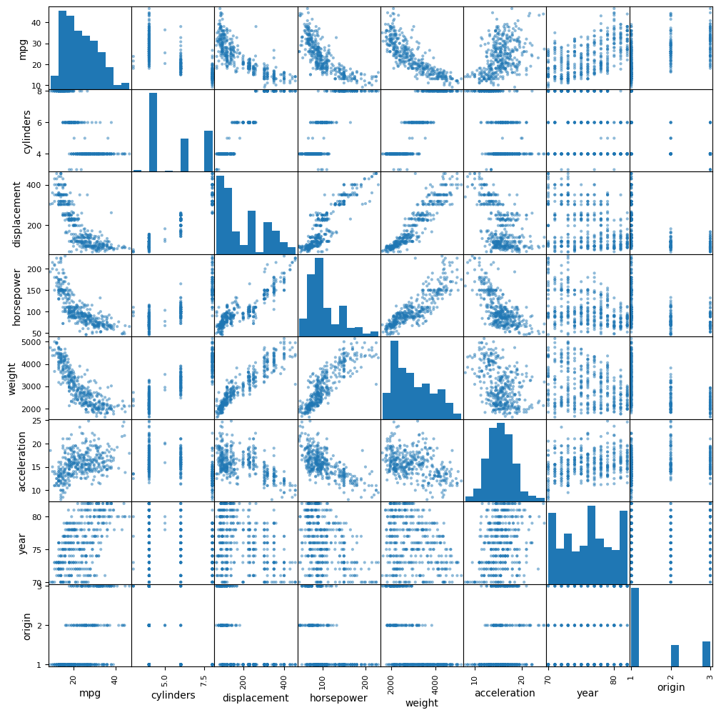

```python
#(a) Produce a scatterplot matrix which includes all of the variables in the data set.
import pandas as pd
import matplotlib.pyplot as plt
from ISLP import load_data

Auto = load_data("Auto")
Auto.head()

pd.plotting.scatter_matrix(Auto, figsize=(12, 12))
plt.show()
```

The scatterplot matrix shows relationships among all of the numeric variables in the Auto data set. There appears to be a strong negative relationship between mpg and variables such as weight, horsepower, and displacement. This means that heavier cars and cars with more horsepower or displacement tend to have lower miles per gallon.

```python
#(b) Compute the matrix of correlations between the variables using the DataFrame.corr() method.

Auto.corr()
```

|  | mpg | cylinders | displacement | horsepower | weight | acceleration | year | origin |
| --- | --- | --- | --- | --- | --- | --- | --- | --- |
| mpg | 1.000000 | -0.777618 | -0.805127 | -0.778427 | -0.832244 | 0.423329 | 0.580541 | 0.565209 |
| cylinders | -0.777618 | 1.000000 | 0.950823 | 0.842983 | 0.897527 | -0.504683 | -0.345647 | -0.568932 |
| displacement | -0.805127 | 0.950823 | 1.000000 | 0.897257 | 0.932994 | -0.543800 | -0.369855 | -0.614535 |
| horsepower | -0.778427 | 0.842983 | 0.897257 | 1.000000 | 0.864538 | -0.689196 | -0.416361 | -0.455171 |
| weight | -0.832244 | 0.897527 | 0.932994 | 0.864538 | 1.000000 | -0.416839 | -0.309120 | -0.585005 |
| acceleration | 0.423329 | -0.504683 | -0.543800 | -0.689196 | -0.416839 | 1.000000 | 0.290316 | 0.212746 |
| year | 0.580541 | -0.345647 | -0.369855 | -0.416361 | -0.309120 | 0.290316 | 1.000000 | 0.181528 |
| origin | 0.565209 | -0.568932 | -0.614535 | -0.455171 | -0.585005 | 0.212746 | 0.181528 | 1.000000 |

The correlation matrix shows that **mpg** has strong negative correlations with **weight** (-0.832), **displacement** (-0.805), **horsepower** (-0.778), and **cylinders** (-0.778). This means that the more heavier and powerful cars will usually have lower mpg. However, **mpg** has positive correlations with **year** (0.581), **origin** (0.565), and **acceleration** (0.423). This means that newer cars of certain origins and with higher acceleration values tend to be associated with a higher mpg.

```python
#(c) Use the sm.OLS() function to perform a multiple linear regression
#with mpg as the response and all other variables except name as
#the predictors. Use the summarize() function to print the results.

import statsmodels.api as sm
from ISLP.models import ModelSpec as MS

X = MS(Auto.columns.drop('mpg')).fit_transform(Auto)
y = Auto['mpg']

model = sm.OLS(y, X)
results = model.fit()

results.summary()
```

OLS Regression Results

| Dep. Variable: | mpg | R-squared: | 0.821 |
| --- | --- | --- | --- |
| Model: | OLS | Adj. R-squared: | 0.818 |
| Method: | Least Squares | F-statistic: | 252.4 |
| Date: | Sun, 21 Jun 2026 | Prob (F-statistic): | 2.04e-139 |
| Time: | 14:06:20 | Log-Likelihood: | -1023.5 |
| No. Observations: | 392 | AIC: | 2063. |
| Df Residuals: | 384 | BIC: | 2095. |
| Df Model: | 7 |  |  |
| Covariance Type: | nonrobust |  |  |

|  | coef | std err | t | P>\|t\| | [0.025 | 0.975] |
| --- | --- | --- | --- | --- | --- | --- |
| intercept | -17.2184 | 4.644 | -3.707 | 0.000 | -26.350 | -8.087 |
| cylinders | -0.4934 | 0.323 | -1.526 | 0.128 | -1.129 | 0.142 |
| displacement | 0.0199 | 0.008 | 2.647 | 0.008 | 0.005 | 0.035 |
| horsepower | -0.0170 | 0.014 | -1.230 | 0.220 | -0.044 | 0.010 |
| weight | -0.0065 | 0.001 | -9.929 | 0.000 | -0.008 | -0.005 |
| acceleration | 0.0806 | 0.099 | 0.815 | 0.415 | -0.114 | 0.275 |
| year | 0.7508 | 0.051 | 14.729 | 0.000 | 0.651 | 0.851 |
| origin | 1.4261 | 0.278 | 5.127 | 0.000 | 0.879 | 1.973 |

| Omnibus: | 31.906 | Durbin-Watson: | 1.309 |
| --- | --- | --- | --- |
| Prob(Omnibus): | 0.000 | Jarque-Bera (JB): | 53.100 |
| Skew: | 0.529 | Prob(JB): | 2.95e-12 |
| Kurtosis: | 4.460 | Cond. No. | 8.59e+04 |

Notes:  
[1] Standard Errors assume that the covariance matrix of the errors is correctly specified.  
[2] The condition number is large, 8.59e+04. This might indicate that there are  
strong multicollinearity or other numerical problems.

**i.** Yes, there appears to be a relationship between the predictors and mpg. The overall F-statistic is 252.4 with a very small p-value, 2.04e-139. Since this p-value is much smaller than 0.05, we reject the null hypothesis and conclude that at least one predictor is related to mpg.

**ii.** The predictors that appear statistically significant are displacement, weight, year, and origin, because their p-values are below 0.05. The variables cylinders, horsepower, and acceleration do not appear statistically significant in this model because their p-values are above 0.05.

**iii.** The coefficient for **year** is 0.7508. This means that, holding the other predictors constant, a one-year increase is associated with an increase of about 0.75 miles per gallon. In other words, newer cars tend to have better gas mileage.

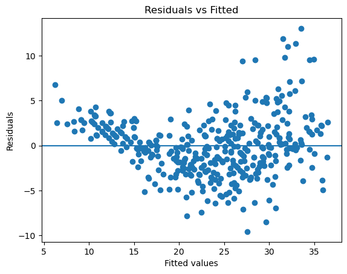

```python
#(d)  Produce some of diagnostic plots of the linear regression fit as
#described in the lab. Comment on any problems you see with the
#fit. Do the residual plots suggest any unusually large outliers?
#Does the leverage plot identify any observations with unusually
#high leverage?

import matplotlib.pyplot as plt
import statsmodels.api as sm

# Residuals vs fitted values
plt.scatter(results.fittedvalues, results.resid)
plt.axhline(0)
plt.xlabel("Fitted values")
plt.ylabel("Residuals")
plt.title("Residuals vs Fitted")
plt.show()
```

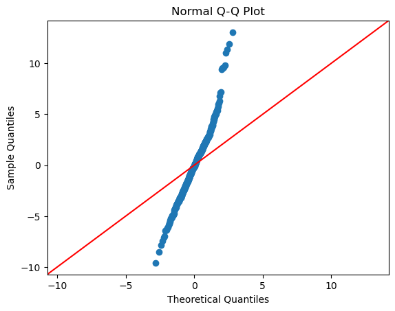

```python
sm.qqplot(results.resid, line="45")
plt.title("Normal Q-Q Plot")
plt.show()
```

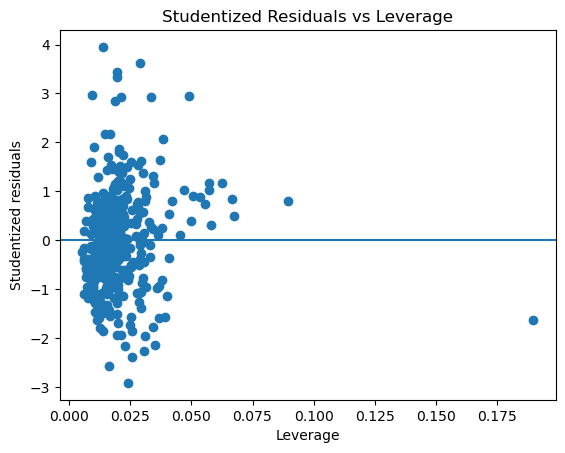

```python
influence = results.get_influence()
leverage = influence.hat_matrix_diag
student_resid = influence.resid_studentized_internal

plt.scatter(leverage, student_resid)
plt.axhline(0)
plt.xlabel("Leverage")
plt.ylabel("Studentized residuals")
plt.title("Studentized Residuals vs Leverage")
plt.show()
```

The residuals vs fitted plot shows a curved pattern rather than a completely random spread, which suggests that there may be some nonlinearity in the data. The Q-Q plot shows that the residuals do not perfectly follow the straight line, especially at the ends, which suggests possible non-normality or outliers. The leverage plot shows one point with much higher leverage than the others, so there may be at least one influential observation.

```python
# Fit some models with interactions as described in the lab. Do
# any interactions appear to be statistically significant?

import statsmodels.formula.api as smf

interaction_model = smf.ols(
    "mpg ~ (cylinders + displacement + horsepower + weight + acceleration + year + origin) ** 2",
    data=Auto
).fit()

interaction_model.summary()
```

OLS Regression Results

| Dep. Variable: | mpg | R-squared: | 0.889 |
| --- | --- | --- | --- |
| Model: | OLS | Adj. R-squared: | 0.881 |
| Method: | Least Squares | F-statistic: | 104.2 |
| Date: | Sun, 21 Jun 2026 | Prob (F-statistic): | 4.01e-155 |
| Time: | 14:33:48 | Log-Likelihood: | -929.72 |
| No. Observations: | 392 | AIC: | 1917. |
| Df Residuals: | 363 | BIC: | 2033. |
| Df Model: | 28 |  |  |
| Covariance Type: | nonrobust |  |  |

|  | coef | std err | t | P>\|t\| | [0.025 | 0.975] |
| --- | --- | --- | --- | --- | --- | --- |
| Intercept | 35.4789 | 53.136 | 0.668 | 0.505 | -69.014 | 139.972 |
| cylinders | 6.9886 | 8.248 | 0.847 | 0.397 | -9.231 | 23.208 |
| displacement | -0.4785 | 0.189 | -2.527 | 0.012 | -0.851 | -0.106 |
| horsepower | 0.5034 | 0.347 | 1.451 | 0.148 | -0.179 | 1.186 |
| weight | 0.0041 | 0.018 | 0.235 | 0.814 | -0.030 | 0.039 |
| acceleration | -5.8592 | 2.174 | -2.696 | 0.007 | -10.134 | -1.585 |
| year | 0.6974 | 0.610 | 1.144 | 0.253 | -0.501 | 1.896 |
| origin | -20.8956 | 7.097 | -2.944 | 0.003 | -34.852 | -6.939 |
| cylinders:displacement | -0.0034 | 0.006 | -0.524 | 0.601 | -0.016 | 0.009 |
| cylinders:horsepower | 0.0116 | 0.024 | 0.480 | 0.632 | -0.036 | 0.059 |
| cylinders:weight | 0.0004 | 0.001 | 0.399 | 0.690 | -0.001 | 0.002 |
| cylinders:acceleration | 0.2779 | 0.166 | 1.670 | 0.096 | -0.049 | 0.605 |
| cylinders:year | -0.1741 | 0.097 | -1.793 | 0.074 | -0.365 | 0.017 |
| cylinders:origin | 0.4022 | 0.493 | 0.816 | 0.415 | -0.567 | 1.371 |
| displacement:horsepower | -8.491e-05 | 0.000 | -0.294 | 0.769 | -0.001 | 0.000 |
| displacement:weight | 2.472e-05 | 1.47e-05 | 1.682 | 0.093 | -4.18e-06 | 5.36e-05 |
| displacement:acceleration | -0.0035 | 0.003 | -1.041 | 0.299 | -0.010 | 0.003 |
| displacement:year | 0.0059 | 0.002 | 2.482 | 0.014 | 0.001 | 0.011 |
| displacement:origin | 0.0240 | 0.019 | 1.232 | 0.219 | -0.014 | 0.062 |
| horsepower:weight | -1.968e-05 | 2.92e-05 | -0.673 | 0.501 | -7.72e-05 | 3.78e-05 |
| horsepower:acceleration | -0.0072 | 0.004 | -1.939 | 0.053 | -0.015 | 0.000 |
| horsepower:year | -0.0058 | 0.004 | -1.482 | 0.139 | -0.014 | 0.002 |
| horsepower:origin | 0.0022 | 0.029 | 0.076 | 0.939 | -0.055 | 0.060 |
| weight:acceleration | 0.0002 | 0.000 | 1.025 | 0.306 | -0.000 | 0.001 |
| weight:year | -0.0002 | 0.000 | -1.056 | 0.292 | -0.001 | 0.000 |
| weight:origin | -0.0006 | 0.002 | -0.364 | 0.716 | -0.004 | 0.003 |
| acceleration:year | 0.0556 | 0.026 | 2.174 | 0.030 | 0.005 | 0.106 |
| acceleration:origin | 0.4583 | 0.157 | 2.926 | 0.004 | 0.150 | 0.766 |
| year:origin | 0.1393 | 0.074 | 1.882 | 0.061 | -0.006 | 0.285 |

| Omnibus: | 47.137 | Durbin-Watson: | 1.664 |
| --- | --- | --- | --- |
| Prob(Omnibus): | 0.000 | Jarque-Bera (JB): | 116.060 |
| Skew: | 0.600 | Prob(JB): | 6.28e-26 |
| Kurtosis: | 5.380 | Cond. No. | 3.76e+08 |

Notes:  
[1] Standard Errors assume that the covariance matrix of the errors is correctly specified.  
[2] The condition number is large, 3.76e+08. This might indicate that there are  
strong multicollinearity or other numerical problems.

Yes, some interaction terms appear to be statistically significant. In particular, displacement:year, acceleration:year, and acceleration:origin have p-values below 0.05. This suggests that the relationship between some predictors and mpg may depend on the value of another predictor. For example, the effect of acceleration on mpg may differ by model year or origin.

```python
#(f) Try a few different transformations of the variables, such as
#log(X),
#√
#X, X2. Comment on your findings.
import numpy as np
transform_model = smf.ols(
    "mpg ~ np.log(horsepower) + np.log(weight) + np.sqrt(displacement) + acceleration + year + origin",
    data=Auto
).fit()

transform_model.summary()
```

OLS Regression Results

| Dep. Variable: | mpg | R-squared: | 0.848 |
| --- | --- | --- | --- |
| Model: | OLS | Adj. R-squared: | 0.846 |
| Method: | Least Squares | F-statistic: | 358.4 |
| Date: | Sun, 21 Jun 2026 | Prob (F-statistic): | 3.61e-154 |
| Time: | 14:38:55 | Log-Likelihood: | -991.77 |
| No. Observations: | 392 | AIC: | 1998. |
| Df Residuals: | 385 | BIC: | 2025. |
| Df Model: | 6 |  |  |
| Covariance Type: | nonrobust |  |  |

|  | coef | std err | t | P>\|t\| | [0.025 | 0.975] |
| --- | --- | --- | --- | --- | --- | --- |
| Intercept | 121.1206 | 11.461 | 10.568 | 0.000 | 98.587 | 143.654 |
| np.log(horsepower) | -5.8252 | 1.561 | -3.733 | 0.000 | -8.893 | -2.757 |
| np.log(weight) | -16.3058 | 2.094 | -7.788 | 0.000 | -20.422 | -12.189 |
| np.sqrt(displacement) | 0.2576 | 0.146 | 1.767 | 0.078 | -0.029 | 0.544 |
| acceleration | -0.1503 | 0.103 | -1.464 | 0.144 | -0.352 | 0.052 |
| year | 0.7374 | 0.047 | 15.649 | 0.000 | 0.645 | 0.830 |
| origin | 1.0617 | 0.261 | 4.067 | 0.000 | 0.548 | 1.575 |

| Omnibus: | 40.727 | Durbin-Watson: | 1.398 |
| --- | --- | --- | --- |
| Prob(Omnibus): | 0.000 | Jarque-Bera (JB): | 77.020 |
| Skew: | 0.606 | Prob(JB): | 1.88e-17 |
| Kurtosis: | 4.801 | Cond. No. | 5.94e+03 |

Notes:  
[1] Standard Errors assume that the covariance matrix of the errors is correctly specified.  
[2] The condition number is large, 5.94e+03. This might indicate that there are  
strong multicollinearity or other numerical problems.

I tried a model using transformations of some predictors, including log(horsepower), log(weight), and sqrt(displacement). The transformed model had an R-squared value of 0.848, which is higher than the original model’s R-squared of 0.821. This suggests that transformations improved the model fit. However, the interaction model had a higher R-squared of 0.889, so the interaction model explained more variation in mpg than the transformed model.

In the transformed model, log(horsepower), log(weight), year, and origin were statistically significant because their p-values were below 0.05.

## 10. This question should be answered using the Carseats data set.

```python
#(a)
Carseats = load_data("Carseats")
Carseats.head()
```

|  | Sales | CompPrice | Income | Advertising | Population | Price | ShelveLoc | Age | Education | Urban | US |
| --- | --- | --- | --- | --- | --- | --- | --- | --- | --- | --- | --- |
| 0 | 9.50 | 138 | 73 | 11 | 276 | 120 | Bad | 42 | 17 | Yes | Yes |
| 1 | 11.22 | 111 | 48 | 16 | 260 | 83 | Good | 65 | 10 | Yes | Yes |
| 2 | 10.06 | 113 | 35 | 10 | 269 | 80 | Medium | 59 | 12 | Yes | Yes |
| 3 | 7.40 | 117 | 100 | 4 | 466 | 97 | Medium | 55 | 14 | Yes | Yes |
| 4 | 4.15 | 141 | 64 | 3 | 340 | 128 | Bad | 38 | 13 | Yes | No |

```python
model_10 = smf.ols(
    "Sales ~ Price + Urban + US",
    data=Carseats
).fit()

model_10.summary()
```

OLS Regression Results

| Dep. Variable: | Sales | R-squared: | 0.239 |
| --- | --- | --- | --- |
| Model: | OLS | Adj. R-squared: | 0.234 |
| Method: | Least Squares | F-statistic: | 41.52 |
| Date: | Sun, 21 Jun 2026 | Prob (F-statistic): | 2.39e-23 |
| Time: | 14:56:53 | Log-Likelihood: | -927.66 |
| No. Observations: | 400 | AIC: | 1863. |
| Df Residuals: | 396 | BIC: | 1879. |
| Df Model: | 3 |  |  |
| Covariance Type: | nonrobust |  |  |

|  | coef | std err | t | P>\|t\| | [0.025 | 0.975] |
| --- | --- | --- | --- | --- | --- | --- |
| Intercept | 13.0435 | 0.651 | 20.036 | 0.000 | 11.764 | 14.323 |
| Urban[T.Yes] | -0.0219 | 0.272 | -0.081 | 0.936 | -0.556 | 0.512 |
| US[T.Yes] | 1.2006 | 0.259 | 4.635 | 0.000 | 0.691 | 1.710 |
| Price | -0.0545 | 0.005 | -10.389 | 0.000 | -0.065 | -0.044 |

| Omnibus: | 0.676 | Durbin-Watson: | 1.912 |
| --- | --- | --- | --- |
| Prob(Omnibus): | 0.713 | Jarque-Bera (JB): | 0.758 |
| Skew: | 0.093 | Prob(JB): | 0.684 |
| Kurtosis: | 2.897 | Cond. No. | 628. |

Notes:  
[1] Standard Errors assume that the covariance matrix of the errors is correctly specified.

The intercept is 13.0435. This is the predicted sales when Price = 0, Urban = No, and US = No. This may not be realistic because a price of 0 does not make much practical sense.

The coefficient for Price is -0.0545. This means that, holding Urban and US constant, each 1-unit increase in price is associated with a decrease of about 0.0545 units in sales.

The coefficient for Urban[T.Yes] is -0.0219. This means that, holding price and US location constant, stores in urban locations are predicted to have sales about 0.0219 lower than stores in non-urban locations. This effect is very small.

The coefficient for US[T.Yes] is 1.2006. This means that, holding price and urban location constant, stores in the US are predicted to have sales about 1.2006 higher than stores outside the US.

### (c)

Predicted sales start at 13.0435. Sales decrease as price increases. Urban stores are predicted to have slightly lower sales, and US stores are predicted to have higher sales.

### (d)

Predicted sales start at 13.0435. Sales decrease as price increases. Urban stores are predicted to have slightly lower sales, and US stores are predicted to have higher sales.

```python
#(e)
model_10_small = smf.ols(
    "Sales ~ Price + US",
    data=Carseats
).fit()

model_10_small.summary()
```

OLS Regression Results

| Dep. Variable: | Sales | R-squared: | 0.239 |
| --- | --- | --- | --- |
| Model: | OLS | Adj. R-squared: | 0.235 |
| Method: | Least Squares | F-statistic: | 62.43 |
| Date: | Sun, 21 Jun 2026 | Prob (F-statistic): | 2.66e-24 |
| Time: | 14:59:34 | Log-Likelihood: | -927.66 |
| No. Observations: | 400 | AIC: | 1861. |
| Df Residuals: | 397 | BIC: | 1873. |
| Df Model: | 2 |  |  |
| Covariance Type: | nonrobust |  |  |

|  | coef | std err | t | P>\|t\| | [0.025 | 0.975] |
| --- | --- | --- | --- | --- | --- | --- |
| Intercept | 13.0308 | 0.631 | 20.652 | 0.000 | 11.790 | 14.271 |
| US[T.Yes] | 1.1996 | 0.258 | 4.641 | 0.000 | 0.692 | 1.708 |
| Price | -0.0545 | 0.005 | -10.416 | 0.000 | -0.065 | -0.044 |

| Omnibus: | 0.666 | Durbin-Watson: | 1.912 |
| --- | --- | --- | --- |
| Prob(Omnibus): | 0.717 | Jarque-Bera (JB): | 0.749 |
| Skew: | 0.092 | Prob(JB): | 0.688 |
| Kurtosis: | 2.895 | Cond. No. | 607. |

Notes:  
[1] Standard Errors assume that the covariance matrix of the errors is correctly specified.

After removing the non-significant predictor Urban, the smaller model includes only Price and US. The fitted model is:

Sales=13.0308−0.0545(Price)+1.1996(USYes)

Both Price and US remain statistically significant because their p-values are below 0.05.

### (f)

The original model and the smaller model have almost the same R-squared value of 0.239. This means both models explain about 23.9% of the variation in Sales. Since removing Urban did not reduce the R-squared value, the smaller model fits about as well as the original model.

```python
#(g)
model_10_small.conf_int()
```

|  | 0 | 1 |
| --- | --- | --- |
| Intercept | 11.79032 | 14.271265 |
| US[T.Yes] | 0.69152 | 1.707766 |
| Price | -0.06476 | -0.044195 |

The 95% confidence interval for the intercept is approximately 11.79 to 14.27. The 95% confidence interval for US[T.Yes] is approximately 0.69 to 1.71. The 95% confidence interval for Price is approximately -0.065 to -0.044.

Since the confidence intervals for US[T.Yes] and Price do not include 0, this supports the conclusion that both predictors are statistically significant. US has a positive relationship with Sales, while Price has a negative relationship with Sales.

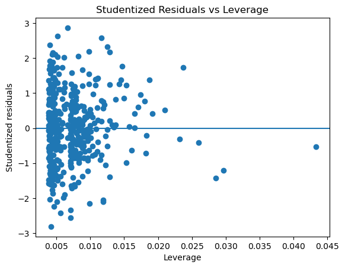

```python
#(h)
import matplotlib.pyplot as plt

influence_10 = model_10_small.get_influence()

leverage_10 = influence_10.hat_matrix_diag
student_resid_10 = influence_10.resid_studentized_internal

plt.scatter(leverage_10, student_resid_10)
plt.axhline(0)
plt.xlabel("Leverage")
plt.ylabel("Studentized residuals")
plt.title("Studentized Residuals vs Leverage")
plt.show()
```

There do not appear to be extreme outliers because the studentized residuals are mostly between -3 and 3. There are a few higher-leverage points, but they do not appear extreme.

## 12. This problem involves simple linear regression without an intercept

### (a)

The coefficient estimates will be the same when the sum of the squared values of X equals the sum of the squared values of Y.

```python
#(b)

rng = np.random.default_rng(1)

x = rng.normal(size=100)
y = 2 * x + rng.normal(size=100)

model_y_on_x = sm.OLS(y, x).fit()
model_x_on_y = sm.OLS(x, y).fit()

print("Y on X coefficient:", model_y_on_x.params[0])
print("X on Y coefficient:", model_x_on_y.params[0])
```

```
Y on X coefficient: 1.9762423774420503
X on Y coefficient: 0.37574368103348876
```

In this example, the coefficient estimate for the regression of Y onto X is approximately 1.9762, while the coefficient estimate for the regression of X onto Y is approximately 0.3757. Since these values are different, this example shows that the two regressions do not generally produce the same coefficient estimate when there is no intercept.

```python
#(c)
rng = np.random.default_rng(2)

x = rng.normal(size=100)
y = x.copy()

model_y_on_x_same = sm.OLS(y, x).fit()
model_x_on_y_same = sm.OLS(x, y).fit()

print("Y on X coefficient:", model_y_on_x_same.params[0])
print("X on Y coefficient:", model_x_on_y_same.params[0])
```

```
Y on X coefficient: 1.0000000000000002
X on Y coefficient: 1.0000000000000002
```

In this example, the coefficient estimate for the regression of Y onto X is approximately 1.0000, and the coefficient estimate for the regression of X onto Y is also approximately 1.0000. The coefficients are the same because X and Y are identical in this example.